# Artificial Neural Network correlation

2017-07-05

## How do we find the limits of accuracy in the `ANN10` correlation

(Kamyab et al. 2010)

## Get `z` at selected `Ppr` and `Tpr`

Use the the correlation to calculate `z` and from Standing-Katz chart obtain `z` a digitized point at the given `Tpr` and `Ppr`.

```r
# get a z value
library(zFactor)
ppr <- 1.5
tpr <- 2.0

z.calc <- z.Ann10(pres.pr = ppr, temp.pr = tpr)
# get a z value from the SK chart at the same Ppr and Tpr
z.chart <- getStandingKatzMatrix(tpr_vector = tpr,
                      pprRange = "lp")[1, as.character(ppr)]

# calculate the APE
ape <- abs((z.calc - z.chart) / z.chart) * 100
df <- as.data.frame(list(Ppr = ppr,  z.calc =z.calc, z.chart = z.chart, ape=ape))
rownames(df) <- tpr
df
# HY = 0.9580002; # DAK = 0.9551087
```

```
  Ppr    z.calc z.chart       ape
2 1.5 0.9572277   0.956 0.1284251
```

## Get `z` at selected `Ppr` and `Tpr=1.1`

From the Standing-Katz chart we read `z` at a digitized point:

```r
library(zFactor)
ppr <- 1.5
tpr <- 1.1

z.calc <- z.Ann10(pres.pr = ppr, temp.pr = tpr)

# From the Standing-Katz chart we obtain a digitized point:
z.chart <- getStandingKatzMatrix(tpr_vector = tpr,
                      pprRange = "lp")[1, as.character(ppr)]

# calculate the APE (Average Percentage Error)
ape <- abs((z.calc - z.chart) / z.chart) * 100
df <- as.data.frame(list(Ppr = ppr,  z.calc =z.calc, z.chart = z.chart, ape=ape))
rownames(df) <- tpr
df
```

```
    Ppr    z.calc z.chart     ape
1.1 1.5 0.4309125   0.426 1.15316
```

> At lower `Tpr` there is some small error. We see a difference between the values of z from the ANN10 calculation and the value read from the Standing-Katz chart.

## Get values of `z` for combinations of `Ppr` and `Tpr`

In this example we provide vectors instead of a single point. With the same `ppr` and `tpr` vectors that we use for the correlation, we do the same for the `Standing-Katz` chart. We want to compare both and find the `absolute percentage error` or `APE`.

```r
# test with 1st-derivative using the values from paper
ppr <- c(0.5, 1.5, 2.5, 3.5, 4.5, 5.5, 6.5)
tpr <- c(1.05, 1.1, 1.7, 2)

# calculate using the correlation
z.calc <- z.Ann10(ppr, tpr)

# With the same ppr and tpr vector, we do the same for the Standing-Katz chart
z.chart <- getStandingKatzMatrix(ppr_vector = ppr, tpr_vector = tpr)
ape <- abs((z.calc - z.chart) / z.chart) * 100

# calculate the APE
cat("z.correlation \n"); print(z.calc)
cat("\n z.chart \n"); print(z.chart)
cat("\n APE \n"); print(ape)
```

```
z.correlation
           0.5       1.5       2.5       3.5       4.5       5.5       6.5
1.05 0.8324799 0.2526076 0.3420322 0.4693520 0.5991874 0.7254470 0.8464481
1.1  0.8547310 0.4309125 0.3930420 0.4983162 0.6136523 0.7278621 0.8417240
1.7  0.9682749 0.9146453 0.8767457 0.8581919 0.8672123 0.8978116 0.9413442
2    0.9839990 0.9572277 0.9414698 0.9352303 0.9453140 0.9693022 1.0014522

 z.chart
       0.5   1.5   2.5   3.5   4.5   5.5   6.5
1.05 0.829 0.253 0.343 0.471 0.598 0.727 0.846
1.10 0.854 0.426 0.393 0.500 0.615 0.729 0.841
1.70 0.968 0.914 0.876 0.857 0.864 0.897 0.942
2.00 0.982 0.956 0.941 0.937 0.945 0.969 1.003

 APE
            0.5        1.5        2.5       3.5        4.5        5.5
1.05 0.41977337 0.15511348 0.28216745 0.3499037 0.19856970 0.21361546
1.1  0.08559949 1.15315985 0.01068849 0.3367504 0.21913422 0.15608683
1.7  0.02839451 0.07060719 0.08512529 0.1390732 0.37179943 0.09048301
2    0.20356328 0.12842505 0.04992300 0.1888697 0.03322296 0.03118282
            6.5
1.05 0.05296786
1.1  0.08608274
1.7  0.06961850
2    0.15431736
```

## Analyze the error at the `isotherms`

Applying the function `summary` over the transpose of the matrix:

```r
sum_t_ape <- summary(t(ape))
sum_t_ape
```

```
      1.05              1.1               1.7                2
 Min.   :0.05297   Min.   :0.01069   Min.   :0.02839   Min.   :0.03118
 1st Qu.:0.17684   1st Qu.:0.08584   1st Qu.:0.07011   1st Qu.:0.04157
 Median :0.21362   Median :0.15609   Median :0.08513   Median :0.12843
 Mean   :0.23887   Mean   :0.29250   Mean   :0.12216   Mean   :0.11279
 3rd Qu.:0.31604   3rd Qu.:0.27794   3rd Qu.:0.11478   3rd Qu.:0.17159
 Max.   :0.41977   Max.   :1.15316   Max.   :0.37180   Max.   :0.20356
```

## Analyze the error for greater values of `Tpr`

```r
library(zFactor)
# enter vectors for Tpr and Ppr
tpr2 <- c(1.2, 1.3, 1.5, 2.0, 3.0)
ppr2 <- c(0.5, 1.5, 2.5, 3.5, 4.5, 5.5)

# get z values from the SK chart
z.chart <- getStandingKatzMatrix(ppr_vector = ppr2, tpr_vector = tpr2, pprRange = "lp")

# We do the same with the HY correlation:
# calculate z values at lower values of Tpr
z.calc <- z.Ann10(pres.pr = ppr2, temp.pr = tpr2)
ape <- abs((z.calc - z.chart) / z.chart) * 100

# calculate the APE
cat("z.correlation \n"); print(z.calc)
cat("\n z.chart \n"); print(z.chart)
cat("\n APE \n"); print(ape)
```

```
z.correlation
          0.5       1.5       2.5       3.5       4.5       5.5
1.2 0.8953923 0.6607512 0.5179963 0.5676801 0.6492856 0.7424365
1.3 0.9196115 0.7567070 0.6394479 0.6341957 0.6857549 0.7611212
1.5 0.9508509 0.8607096 0.7940885 0.7685691 0.7867923 0.8323518
2   0.9839990 0.9572277 0.9414698 0.9352303 0.9453140 0.9693022
3   1.0028553 1.0095269 1.0179196 1.0286167 1.0412701 1.0563968

 z.chart
       0.5   1.5   2.5   3.5   4.5   5.5
1.20 0.893 0.657 0.519 0.565 0.650 0.741
1.30 0.916 0.756 0.638 0.633 0.684 0.759
1.50 0.948 0.859 0.794 0.770 0.790 0.836
2.00 0.982 0.956 0.941 0.937 0.945 0.969
3.00 1.002 1.009 1.018 1.029 1.041 1.056

 APE
           0.5        1.5         2.5        3.5        4.5        5.5
1.2 0.26789648 0.57095444 0.193394633 0.47434588 0.10991106 0.19385949
1.3 0.39427385 0.09352066 0.226947481 0.18889818 0.25656553 0.27947684
1.5 0.30073289 0.19902087 0.011147992 0.18583440 0.40603584 0.43638788
2   0.20356328 0.12842505 0.049923003 0.18886972 0.03322296 0.03118282
3   0.08535489 0.05221529 0.007894686 0.03724608 0.02594419 0.03757710
```

## Analyze the error at the `isotherms`

Applying the function `summary` over the transpose of the matrix to observe the error of the correlation at each isotherm.

```r
sum_t_ape <- summary(t(ape))
sum_t_ape
 # Hall-Yarborough
 #      1.2               1.3              1.5               2
 # Min.   :0.05224   Min.   :0.1105   Min.   :0.1021   Min.   :0.0809
 # 1st Qu.:0.09039   1st Qu.:0.2080   1st Qu.:0.1623   1st Qu.:0.1814
 # Median :0.28057   Median :0.3181   Median :0.1892   Median :0.1975
 # Mean   :0.30122   Mean   :0.3899   Mean   :0.2597   Mean   :0.2284
 # 3rd Qu.:0.51710   3rd Qu.:0.5355   3rd Qu.:0.3533   3rd Qu.:0.2627
 # Max.   :0.57098   Max.   :0.8131   Max.   :0.5162   Max.   :0.4338
 #       3
 # Min.   :0.09128
 # 1st Qu.:0.17466
 # Median :0.35252
 # Mean   :0.34820
 # 3rd Qu.:0.52184
 # Max.   :0.59923
```

```
      1.2              1.3               1.5                2
 Min.   :0.1099   Min.   :0.09352   Min.   :0.01115   Min.   :0.03118
 1st Qu.:0.1935   1st Qu.:0.19841   1st Qu.:0.18913   1st Qu.:0.03740
 Median :0.2309   Median :0.24176   Median :0.24988   Median :0.08917
 Mean   :0.3017   Mean   :0.23995   Mean   :0.25653   Mean   :0.10586
 3rd Qu.:0.4227   3rd Qu.:0.27375   3rd Qu.:0.37971   3rd Qu.:0.17376
 Max.   :0.5710   Max.   :0.39427   Max.   :0.43639   Max.   :0.20356
       3
 Min.   :0.007895
 1st Qu.:0.028770
 Median :0.037412
 Mean   :0.041039
 3rd Qu.:0.048556
 Max.   :0.085355
```

## Prepare to plot SK vs N10 correlation

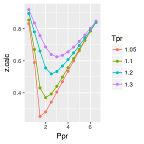

```
# A tibble: 52 x 5
     Tpr   Ppr z.chart    z.calc           dif
   <chr> <dbl>   <dbl>     <dbl>         <dbl>
 1  1.05   0.5   0.829 0.8324799 -0.0034799212
 2   1.1   0.5   0.854 0.8547310 -0.0007310197
 3   1.2   0.5   0.893 0.8953923 -0.0023923156
 4   1.3   0.5   0.916 0.9196115 -0.0036115485
 5  1.05   1.0   0.589 0.5896265 -0.0006265401
 6   1.1   1.0   0.669 0.6708697 -0.0018696755
 7   1.2   1.0   0.779 0.7807145 -0.0017144762
 8   1.3   1.0   0.835 0.8363278 -0.0013277938
 9  1.05   1.5   0.253 0.2526076  0.0003924371
10   1.1   1.5   0.426 0.4309125 -0.0049124610
# ... with 42 more rows
```

```r
library(zFactor)
library(tibble)
library(ggplot2)

tpr2 <- c(1.05, 1.1, 1.2, 1.3)
ppr2 <- c(0.5, 1.0, 1.5, 2, 2.5, 3.0, 3.5, 4.0, 4.5, 5.0, 5.5, 6.0, 6.5)

sk_dak_2 <- createTidyFromMatrix(ppr2, tpr2, correlation = "N10")
as.tibble(sk_dak_2)

p <- ggplot(sk_dak_2, aes(x=Ppr, y=z.calc, group=Tpr, color=Tpr)) +
    geom_line() +
    geom_point() +
    geom_errorbar(aes(ymin=z.calc-dif, ymax=z.calc+dif), width=.4,
                  position=position_dodge(0.05))
print(p)
```

## Analysis at the lowest `Tpr`

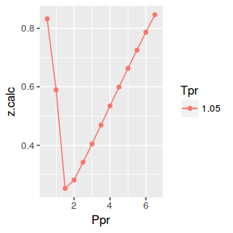

```
    Tpr Ppr z.chart    z.calc           dif
1  1.05 0.5   0.829 0.8324799 -0.0034799212
5  1.05 1.0   0.589 0.5896265 -0.0006265401
9  1.05 1.5   0.253 0.2526076  0.0003924371
13 1.05 2.0   0.280 0.2813986 -0.0013986023
17 1.05 2.5   0.343 0.3420322  0.0009678343
21 1.05 3.0   0.407 0.4046718  0.0023282390
25 1.05 3.5   0.471 0.4693520  0.0016480466
29 1.05 4.0   0.534 0.5347267 -0.0007266737
33 1.05 4.5   0.598 0.5991874 -0.0011874468
37 1.05 5.0   0.663 0.6627276  0.0002723595
41 1.05 5.5   0.727 0.7254470  0.0015529844
45 1.05 6.0   0.786 0.7868394 -0.0008393750
49 1.05 6.5   0.846 0.8464481 -0.0004481081
```

```r
library(zFactor)

sk_dak_3 <- sk_dak_2[sk_dak_2$Tpr==1.05,]
sk_dak_3

p <- ggplot(sk_dak_3, aes(x=Ppr, y=z.calc, group=Tpr, color=Tpr)) +
    geom_line() +
    geom_point() +
    geom_errorbar(aes(ymin=z.calc-dif, ymax=z.calc+dif), width=.2,
                  position=position_dodge(0.05))
print(p)
```

## Analyzing performance of the `N10` correlation for all the `Tpr` curves

In this last example, we compare the values of `z` at all the isotherms. We use the function `getStandingKatzTpr` to obtain all the isotherms or `Tpr` curves in the Standing-Katz chart that have been digitized. The next function `createTidyFromMatrix` calculates `z` using the correlation and prepares a tidy dataset ready to plot.

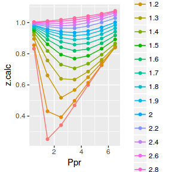

```
# A tibble: 112 x 5
     Tpr   Ppr z.chart    z.calc           dif
   <chr> <dbl>   <dbl>     <dbl>         <dbl>
 1  1.05   0.5   0.829 0.8324799 -0.0034799212
 2   1.1   0.5   0.854 0.8547310 -0.0007310197
 3   1.2   0.5   0.893 0.8953923 -0.0023923156
 4   1.3   0.5   0.916 0.9196115 -0.0036115485
 5   1.4   0.5   0.936 0.9367118 -0.0007118312
 6   1.5   0.5   0.948 0.9508509 -0.0028509478
 7   1.6   0.5   0.959 0.9607316 -0.0017315940
 8   1.7   0.5   0.968 0.9682749 -0.0002748589
 9   1.8   0.5   0.974 0.9758251 -0.0018251256
10   1.9   0.5   0.978 0.9814269 -0.0034269385
# ... with 102 more rows
```

```r
library(ggplot2)
library(tibble)

# get all `lp` Tpr curves
tpr_all <- getStandingKatzTpr(pprRange = "lp")
ppr <- c(0.5, 1.5, 2.5, 3.5, 4.5, 5.5, 6.5)
sk_corr_all <- createTidyFromMatrix(ppr, tpr_all, correlation = "N10")
as.tibble(sk_corr_all)

p <- ggplot(sk_corr_all, aes(x=Ppr, y=z.calc, group=Tpr, color=Tpr)) +
    geom_line() +
    geom_point() +
    geom_errorbar(aes(ymin=z.calc-dif, ymax=z.calc+dif), width=.4,
                  position=position_dodge(0.05))
print(p)
```

## Range of applicability of the correlation

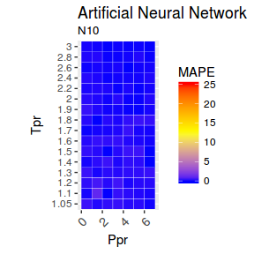

```r
# MSE: Mean Squared Error
# RMSE: Root Mean Squared Error
# RSS: residual sum of square
# ARE:  Average Relative Error, %
# AARE: Average Absolute Relative Error, %
library(dplyr)
grouped <- group_by(sk_corr_all, Tpr, Ppr)

smry_tpr_ppr <- summarise(grouped,
          RMSE= sqrt(mean((z.chart-z.calc)^2)),
          MPE = sum((z.calc - z.chart) / z.chart) * 100 / n(),
          MAPE = sum(abs((z.calc - z.chart) / z.chart)) * 100 / n(),
          MSE = sum((z.calc - z.chart)^2) / n(),
          RSS = sum((z.calc - z.chart)^2),
          MAE = sum(abs(z.calc - z.chart)) / n(),
          RMLSE = sqrt(1/n()*sum((log(z.calc +1)-log(z.chart +1))^2))
          )

ggplot(smry_tpr_ppr, aes(Ppr, Tpr)) +
    geom_tile(data=smry_tpr_ppr, aes(fill=MAPE), color="white") +
    scale_fill_gradient2(low="blue", high="red", mid="yellow", na.value = "pink",
                         midpoint=12.5, limit=c(0, 25), name="MAPE") +
    theme(axis.text.x = element_text(angle=45, vjust=1, size=11, hjust=1)) +
    coord_equal() +
    ggtitle("Artificial Neural Network", subtitle = "N10")
```

## Plotting the `Tpr` and `Ppr` values that show more error

The `MAPE` (mean average percentage error) gradient bar indicates that the more red the square is, the more error there is.

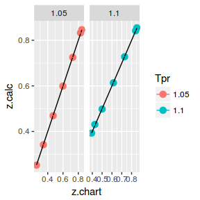

```r
library(dplyr)

sk_corr_all %>%
    filter(Tpr %in% c("1.05", "1.1")) %>%
    ggplot(aes(x = z.chart, y=z.calc, group = Tpr, color = Tpr)) +
    geom_point(size = 3) +
    geom_line(aes(x = z.chart, y = z.chart), color = "black") +
    facet_grid(. ~ Tpr, scales = "free") +
    geom_errorbar(aes(ymin=z.calc-abs(dif), ymax=z.calc+abs(dif)),
                  position=position_dodge(0.5))
```

## Looking numerically at the errors

Finally, the dataframe with the calculated errors between the `z` from the correlation and the `z` read from the chart:

```r
as.tibble(smry_tpr_ppr)
```

```
# A tibble: 112 x 9
# Groups:   Tpr [?]
     Tpr   Ppr         RMSE         MPE       MAPE          MSE
   <chr> <dbl>        <dbl>       <dbl>      <dbl>        <dbl>
 1  1.05   0.5 3.479921e-03  0.41977337 0.41977337 1.210985e-05
 2  1.05   1.5 3.924371e-04 -0.15511348 0.15511348 1.540069e-07
 3  1.05   2.5 9.678343e-04 -0.28216745 0.28216745 9.367033e-07
 4  1.05   3.5 1.648047e-03 -0.34990374 0.34990374 2.716058e-06
 5  1.05   4.5 1.187447e-03  0.19856970 0.19856970 1.410030e-06
 6  1.05   5.5 1.552984e-03 -0.21361546 0.21361546 2.411761e-06
 7  1.05   6.5 4.481081e-04  0.05296786 0.05296786 2.008009e-07
 8   1.1   0.5 7.310197e-04  0.08559949 0.08559949 5.343898e-07
 9   1.1   1.5 4.912461e-03  1.15315985 1.15315985 2.413227e-05
10   1.1   2.5 4.200577e-05  0.01068849 0.01068849 1.764485e-09
# ... with 102 more rows, and 3 more variables: RSS <dbl>, MAE <dbl>,
#   RMLSE <dbl>
```

## References

Kamyab, Mohammadreza, Jorge HB Sampaio, Farhad Qanbari, and Alfred W Eustes. 2010. “Using Artificial Neural Networks to Estimate the Z-Factor for Natural Hydrocarbon Gases.” *Journal of Petroleum Science and Engineering* 73 (3). Elsevier: 248–57. doi:10.1016/j.petrol.2010.07.006.